# dataset_tidy

Autogenerated data summary from dataMaid

2023-12-07 22:36:19.054629

# Data report overview

The dataset examined has the following dimensions:

| Feature | Result |
| --- | --- |
| Number of observations | 10 |
| Number of variables | 5 |

- Only variables that were deemed potentially problematic are included in this summary.

### Checks performed

The following variable checks were performed, depending on the data type of each variable:

|  | character | factor | labelled | haven labelled | numeric | integer | logical | Date |
| --- | --- | --- | --- | --- | --- | --- | --- | --- |
| Identify miscoded missing values | × | × | × | × | × | × |  | × |
| Identify prefixed and suffixed whitespace | × | × | × | × |  |  |  |  |
| Identify levels with < 6 obs. | × | × | × | × |  |  |  |  |
| Identify case issues | × | × | × | × |  |  |  |  |
| Identify misclassified numeric or integer variables | × | × | × | × |  |  |  |  |
| Identify outliers |  |  |  |  | × | × |  | × |

Please note that all numerical values in the following have been rounded to 2 decimals.

# Codebook summary table

| Label | Variable | Class | # unique values | Missing | Description |
| --- | --- | --- | --- | --- | --- |
|  | **Stratum…i.** | integer | 2 | 0.00 % |  |
|  | **Plot..sp.** | integer | 2 | 0.00 % |  |
|  | **Species..j.** | character | 6 | 0.00 % |  |
|  | **Tree..l.** | character | 5 | 0.00 % |  |
|  | **Volume..V_.l.j.I.sp..** | numeric | 10 | 0.00 % |  |

# Variable list

## Stratum…i.

- Note that this variable is treated as a factor variable below, as it only takes a few unique values.

| Feature | Result |
| --- | --- |
| Variable type | integer |
| Number of missing obs. | 0 (0 %) |
| Number of unique values | 2 |
| Mode | “1” |
| Reference category | 1 |

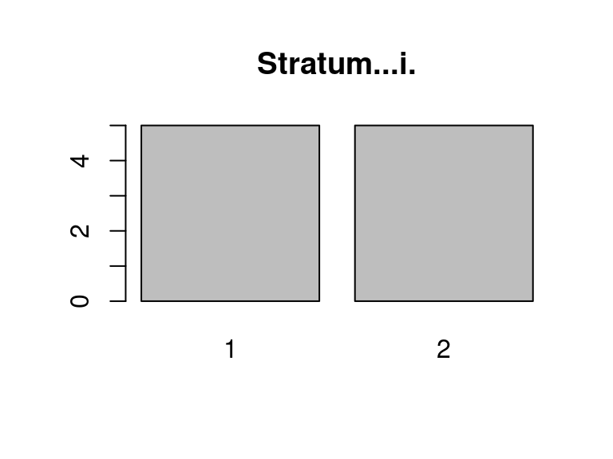

- Note that the following levels have at most five observations: "1", "2".

## Plot..sp.

- Note that this variable is treated as a factor variable below, as it only takes a few unique values.

| Feature | Result |
| --- | --- |
| Variable type | integer |
| Number of missing obs. | 0 (0 %) |
| Number of unique values | 2 |
| Mode | “1” |
| Reference category | 1 |

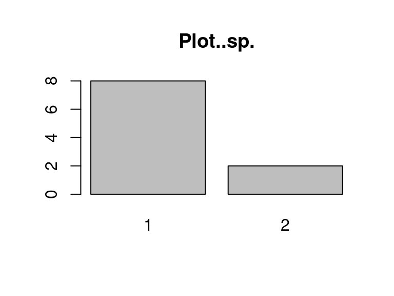

- Note that the following levels have at most five observations: "2".

## Species..j.

| Feature | Result |
| --- | --- |
| Variable type | character |
| Number of missing obs. | 0 (0 %) |
| Number of unique values | 6 |
| Mode | “Sp1” |

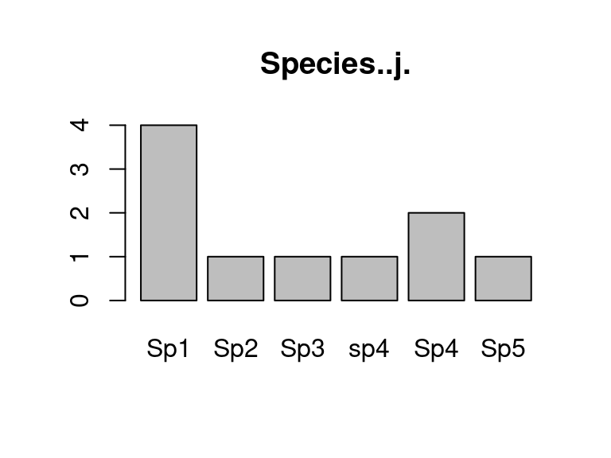

- Note that the following levels have at most five observations: "Sp1", "Sp2", "Sp3", "sp4", "Sp4", "Sp5".
- Note that there might be case problems with the following levels: "sp4", "Sp4".

## Tree..l.

| Feature | Result |
| --- | --- |
| Variable type | character |
| Number of missing obs. | 0 (0 %) |
| Number of unique values | 5 |
| Mode | “t1” |

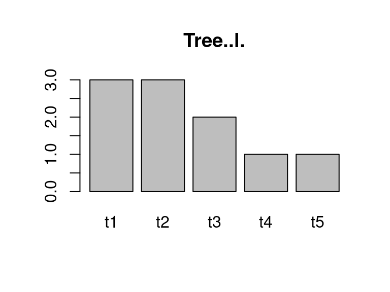

- Note that the following levels have at most five observations: "t1", "t2", "t3", "t4", "t5".

## Volume..V_.l.j.I.sp..

| Feature | Result |
| --- | --- |
| Variable type | numeric |
| Number of missing obs. | 0 (0 %) |
| Number of unique values | 10 |
| Median | 3.27 |
| 1st and 3rd quartiles | 2; 3.63 |
| Min. and max. | 1.38; 4.8 |

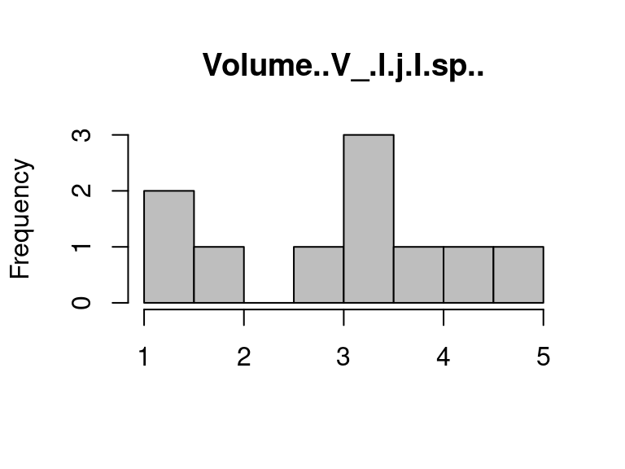

- Note that the following possible outlier values were detected: "4.8".

Report generation information:

- Created by: seamusrobertmurphy (username: `seamus`).
- Report creation time: Thu Dec 07 2023 22:36:19
- Report was run from directory: `/home/seamus/Desktop/git_repos/verra-stage1-GHG-tool`
- dataMaid v1.4.1 [Pkg: 2021-10-08 from CRAN (R 4.3.2)]
- R version 4.3.2 (2023-10-31).
- Platform: x86_64-pc-linux-gnu (64-bit)(Europe/London).
- Function call: `dataMaid::makeDataReport(data = dataset_tidy, output = "html", onlyProblematic = TRUE, replace = TRUE, visuals = setVisuals(all = "basicVisual"), codebook = TRUE)`